# Project 3, Part 2: Data Analysis Project Pipeline

Brad Scurlock

22 Aug 21

## **Load data**

```r
# Load the my_gapminder and my_penguins data sets from .csv files.
my_gapminder <- read.csv("../Data/my_gapminder.csv",
                         header = TRUE,
                         stringsAsFactors = TRUE)
my_penguins <- read.csv("../Data/my_penguins.csv",
                        header = TRUE,
                        stringsAsFactors = TRUE)
```

## **Load source**

```r
# Load my_rf_cv.R() by sourcing it.
source("../Code/my_rf_cv.R")
```

## **`my_rf_cv()`**

`my_rf_cv()` applies cross-validation to a random forest algorithm (`randomForest()` from the `randomForest` package). This function is hard-wired to work solely on the `my_penguins` data set; the only meaningful parameter (an additional `feedback` parameter exists solely for debugging) is `k` which represents the desired number of cross-validation folds.

Below we predict body mass (`body_mass_g`) (classification = y) using three characteristics (covariates = x): bill length (`bill_length_mm`), bill depth (`bill_depth_mm`), and flipper length (`flipper_length_mm`). Cross-validation is applied using fold counts of 2, 5, and finally 10 to the random forest algorithm, 30 times per each of the three specified fold counts.

```r
# Cross-validation fold counts.
folds <- c(2, 5, 10)
# Number of simulations to run for each fold count.
iterations <- 30
# Matrix to gather results for table.
results <- matrix(nrow = iterations, ncol = length(folds))
# Successively apply random forest algorithm using cross-validation for
# each fold count specified..
for (k in 1:length(folds)) {
  for (iteration in 1:iterations) {
    # tmp <- my_rf_cv(folds[k])
    # cat("results[", iteration, ", ", k, "]: ", tmp, "\n")
    results[iteration, k] <- my_rf_cv(folds[k])
  }
}
```

The resulting cross-validation estimated mean squared errors (MSEs) for each fold count (`k`) are depicted in the following boxplots (outliers in solid grey circles):

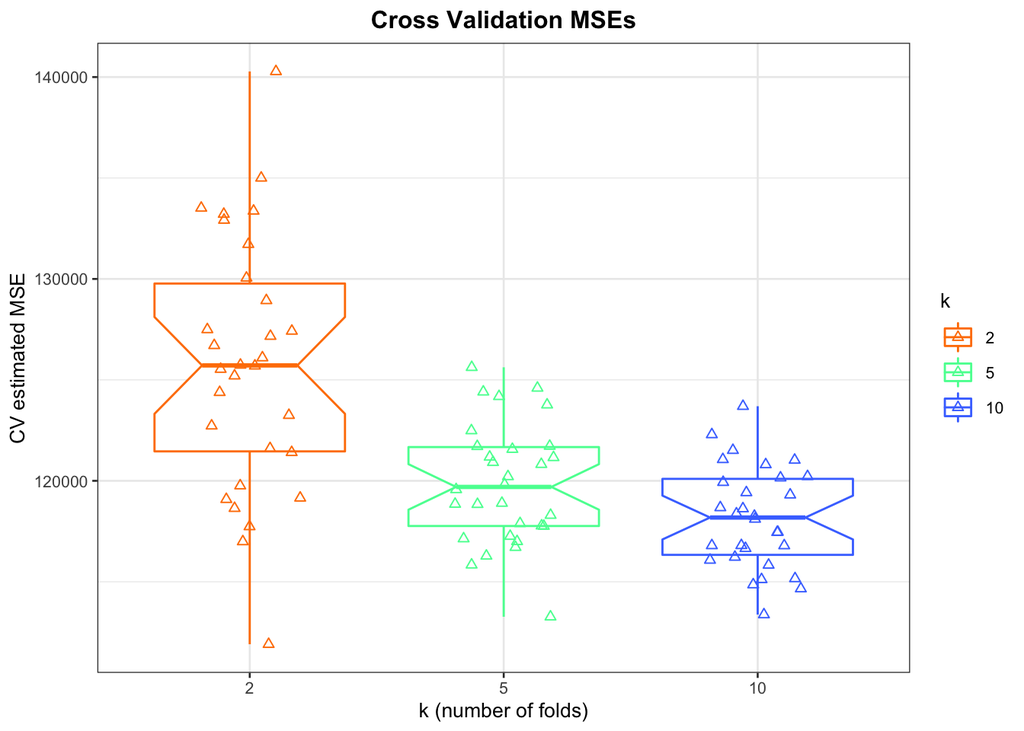

```r
# Convert from matrix to data.frame for ggplot2.
mse_df <- data.frame(k = as.factor(rep(folds, each = iterations)),
                     mse = c(results[, 1], results[, 2], results[, 3]))

# Generate a boxplot for each fold count.
cvmse <- ggplot(data = mse_df, aes(x = k, y = mse, color = k)) +
  geom_boxplot(outlier.colour = "grey68",
               outlier.shape = 16,
               outlier.size = 2,
               notch = TRUE) +
  geom_jitter(shape = 2, position = position_jitter(0.2)) +
  scale_color_manual(values =c ("darkorange1", "seagreen1", "royalblue1")) +
  theme_bw(base_size = 10) +
  labs(x = "k (number of folds)",
       y = "CV estimated MSE",
       title = "Cross Validation MSEs") +
  theme(plot.title = element_text(hjust = 0.5, face = "bold"))
cvmse
```

The resulting mean and standard deviation of the cross-validation estimated MSEs for each fold count (`k`) are presented below:

```r
# Convert from matrix to data.frame for kable table.
synopsis <- data.frame(
  "average" = rep(NA, times = ncol(results)),
  "stdev" = rep(NA, times = ncol(results))
)
rn <- rep(NA, times = ncol(results))

# Display mean and standard deviation for each fold.
for (i in 1:length(folds)) {
  synopsis[i, 1] <- mean(results[, i])
  synopsis[i, 2] <- sd(results[, i])
  rn[i] <- paste("k (number of folds) = ", folds[i])
}

# Label table.
rownames(synopsis) <- rn
colnames(synopsis) <- c("Mean CV Estimate", "Standard Deviation CV Estimate")

cves <- kable_styling(kable(synopsis))
cves
```

|  | Mean CV Estimate | Standard Deviation CV Estimate |
| --- | --- | --- |
| k (number of folds) = 2 | 125756.7 | 6312.942 |
| k (number of folds) = 5 | 119851.8 | 2968.247 |
| k (number of folds) = 10 | 118157.6 | 2519.731 |

The above boxplots depict the cross-validation estimated MSEs visually while the above table depicts said data textually. They both suggest that as the number of cross-validation folds increases, both the mean and standard deviations of the cross-validation MSEs, which is what I’d expect.

## **Save boxplots figure, cv estimate table, and simulated rf results**

The following code saves the boxplots, table, and results.

```r
# Save MSE boxplots as PDF.
ggsave("../Output/Figures/cvmse.pdf", plot = cvmse)
# Save CV Estimate table as RDS.
saveRDS(object = cves, file = "../Output/Results/cves.rds")
# One column for each k.
results_df <- data.frame(k2 = results[, 1],
                         k5 = results[, 2],
                         k10 = results[, 3])
# Save results of random forest iterations as CSV.
write.csv(results_df, file="../Output/Results/results_df.csv",
          row.names = FALSE)
```

I verified the timestamp changed on the three resultant output files following each successive knit of this document.